# Group Project - Group #41

STAT 420, Summer 2018, Gassan Soukaev, Hanna Loboda, Hao Tang, You Li

```r
options(scipen = 1, digits = 4, width = 80, fig.align = "center")
```

## Introduction

### Team

- Gassan Soukaev (soukaev2)
- Hanna Loboda (hloboda2)
- Hao Tang (haot3)
- You Li (youl3)

### Project Description

Titanic - Who was likely to survive?

“The sinking of the RMS Titanic is one of the most infamous shipwrecks in history. On April 15, 1912, during her maiden voyage, the Titanic sank after colliding with an iceberg, killing 1502 out of 2224 passengers and crew. This sensational tragedy shocked the international community and led to better safety regulations for ships.

One of the reasons that the shipwreck led to such loss of life was that there were not enough lifeboats for the passengers and crew. Although there was some element of luck involved in surviving the sinking, some groups of people were more likely to survive than others, such as women, children, and the upper-class.”

The purpose of this analysis will be to ascertain any patterns in the survival of the passengers by identifying any attributes that would make you more likely to survive amidst all the chaos.

### Data

```r
ptitanic = read.csv("train.csv")
str(ptitanic)
```

```
## 'data.frame':    891 obs. of  12 variables:
##  $ PassengerId: int  1 2 3 4 5 6 7 8 9 10 ...
##  $ Survived   : int  0 1 1 1 0 0 0 0 1 1 ...
##  $ Pclass     : int  3 1 3 1 3 3 1 3 3 2 ...
##  $ Name       : Factor w/ 891 levels "Abbing, Mr. Anthony",..: 109 191 358 277 16 559 520 629 417 581 ...
##  $ Sex        : Factor w/ 2 levels "female","male": 2 1 1 1 2 2 2 2 1 1 ...
##  $ Age        : num  22 38 26 35 35 NA 54 2 27 14 ...
##  $ SibSp      : int  1 1 0 1 0 0 0 3 0 1 ...
##  $ Parch      : int  0 0 0 0 0 0 0 1 2 0 ...
##  $ Ticket     : Factor w/ 681 levels "110152","110413",..: 524 597 670 50 473 276 86 396 345 133 ...
##  $ Fare       : num  7.25 71.28 7.92 53.1 8.05 ...
##  $ Cabin      : Factor w/ 148 levels "","A10","A14",..: 1 83 1 57 1 1 131 1 1 1 ...
##  $ Embarked   : Factor w/ 4 levels "","C","Q","S": 4 2 4 4 4 3 4 4 4 2 ...
```

This dataset is available at kaggle: https://www.kaggle.com/c/titanic/data

Response:

- survival is the response variable (0 = No, 1 = Yes)

Predictors:

- Pclass - Ticket class (1 = 1st, 2 = 2nd, 3 = rd)
- Sex (Male, Female)
- Age - Age in years (Numeric)
- SibSp - Number of siblings / spouses aboard the Titanic
- parch - Number of parents / children aboard the Titanic
- ticket - Ticket number
- fare - Passenger fare
- cabin - Cabin number
- embarked - Port of Embarkation (C = Cherbourg, Q = Queenstown, S = Southampton)

## Methods

### Data cleaning

- First of all let’s do some data cleanup
- We don’t need columns such as PassengerID, Name, Ticket # as they have no impact on our statistical analysis
- Let’s remove them leaving only numeric and factor columns

```r
ptitanic = subset(ptitanic, select = c(2, 3, 5, 6, 7, 8, 10, 12))
ptitanic$Survived = as.factor(ptitanic$Survived)
levels(ptitanic$Survived) <- c("No", "Yes")
head(ptitanic)
```

```
##   Survived Pclass    Sex Age SibSp Parch   Fare Embarked
## 1       No      3   male  22     1     0  7.250        S
## 2      Yes      1 female  38     1     0 71.283        C
## 3      Yes      3 female  26     0     0  7.925        S
## 4      Yes      1 female  35     1     0 53.100        S
## 5       No      3   male  35     0     0  8.050        S
## 6       No      3   male  NA     0     0  8.458        Q
```

- Now let’s see if we have missing values

```r
apply(is.na(ptitanic),2,sum)
```

```
## Survived   Pclass      Sex      Age    SibSp    Parch     Fare Embarked
##        0        0        0      177        0        0        0        0
```

- Yes, out of 891 rows we have 177 records with missing Age which is quite substantial chunk of data
- Removing all of them may not be as good of an idea since it represents 20% of the total training data
- We will replace NA values with the average age (which happens to be 30)

```r
library(zoo)
ptitanic$Age = round(na.aggregate(ptitanic$Age))
```

- Let’s check for missing values now

```r
apply(is.na(ptitanic),2,sum)
```

```
## Survived   Pclass      Sex      Age    SibSp    Parch     Fare Embarked
##        0        0        0        0        0        0        0        0
```

- There are two values of Embarked with blank values so we will remove them as well

```r
ptitanic = ptitanic[-which(ptitanic$Embarked == ""), ]
```

### Divide the data into train and test datasets

```r
set.seed(42)
n = nrow(ptitanic)
trainIndex = sample(1:n, size = round(0.7*n), replace=FALSE)
ptitanic_trn = ptitanic[trainIndex ,]
ptitanic_tst = ptitanic[-trainIndex ,]
```

### Data Analysis

- All good! Ready to do the analysis. Let’s get to know our data. Let’s take a look at pairs plot and look for any patterns or collinearity among the predictors

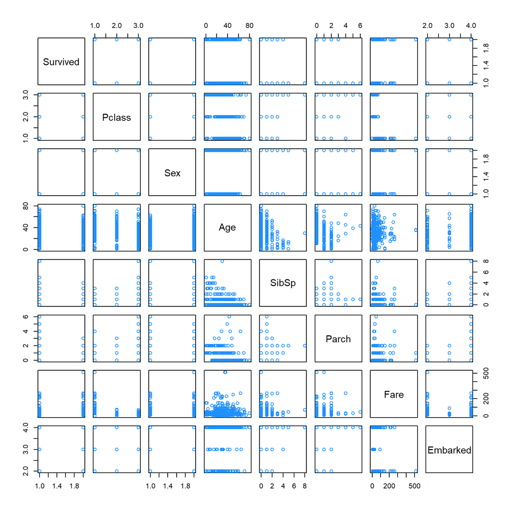

```r
pairs(ptitanic_trn, col = "dodgerblue")
```

- No clear patterns or collinearity issues can be seen
- Let’s take a quick look at collinearity matrix for numeric variables

```r
round(cor(ptitanic_trn[c(2, 4:7)]), 2)
```

```
##        Pclass   Age SibSp Parch  Fare
## Pclass   1.00 -0.32  0.08  0.03 -0.54
## Age     -0.32  1.00 -0.21 -0.23  0.06
## SibSp    0.08 -0.21  1.00  0.42  0.17
## Parch    0.03 -0.23  0.42  1.00  0.22
## Fare    -0.54  0.06  0.17  0.22  1.00
```

- The collinearity matrix shows some collinearity between number of parents / children aboard and # of siblings / spouses aboard which makes sense
- There is also some collinearity between Fare and Ticket class which also makes sense
- Let’s also take a look who survived by age

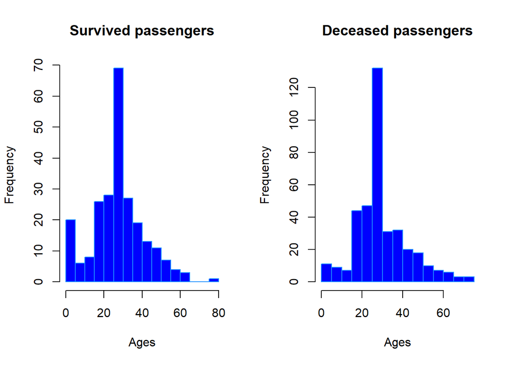

```r
survived = ptitanic_trn[ptitanic_trn$Survived == "Yes", ]$Age
died = ptitanic_trn[ptitanic_trn$Survived == "No", ]$Age

par(mfrow = c(1, 2))
hist(survived, main="Survived passengers",
     xlab="Ages", border="dodgerblue", col="blue", breaks=20)

hist(died, main="Deceased passengers",
     xlab="Ages", border="dodgerblue", col="blue", breaks=20)
```

- Let’s also take a look at relationship between age / fare / death

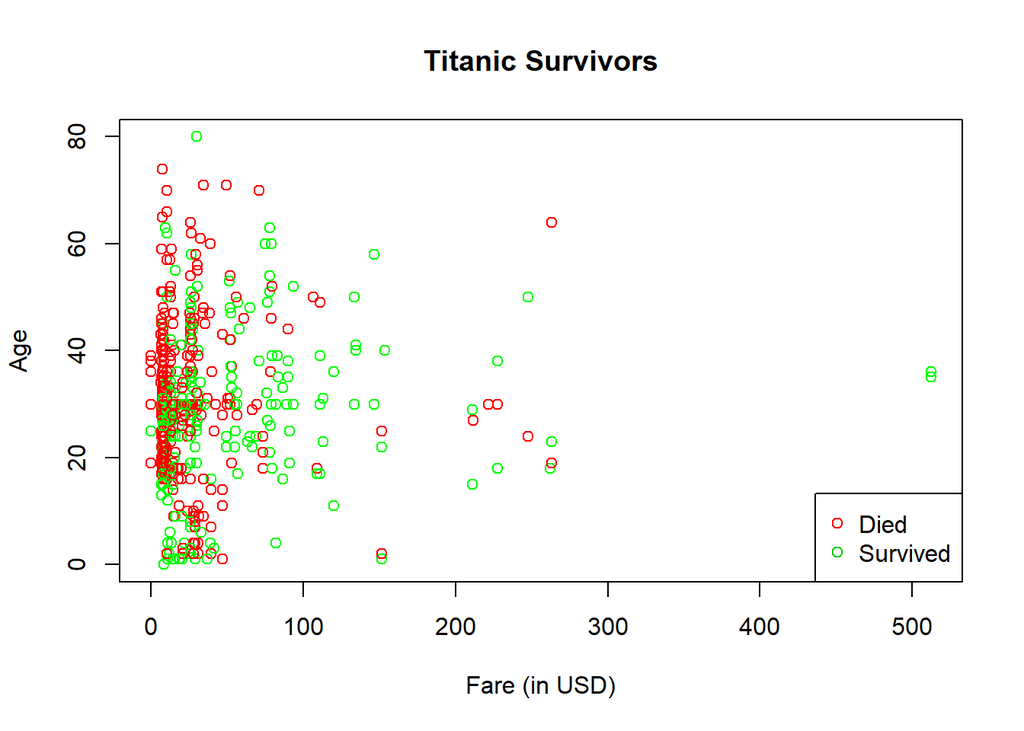

```r
plot(ptitanic_trn$Fare, ptitanic_trn$Age, main="Titanic Survivors",
     xlab="Fare (in USD)", ylab="Age", pch = 1,
     col = ifelse(ptitanic_trn$Survived=="Yes", "green", "red"))
legend("bottomright", c("Died", "Survived"), pch = 1, col = c(2, 3))
```

### Modeling

- Time to start looking at the linear regression models
- Let’s start with building a simple additive model

```r
add_model = glm(Survived ~ ., data = ptitanic_trn, family = binomial)
summary(add_model)
```

```
##
## Call:
## glm(formula = Survived ~ ., family = binomial, data = ptitanic_trn)
##
## Deviance Residuals:
##    Min      1Q  Median      3Q     Max
## -2.604  -0.612  -0.415   0.611   2.403
##
## Coefficients:
##              Estimate Std. Error z value Pr(>|z|)
## (Intercept)  5.491704   0.656685    8.36  < 2e-16 ***
## Pclass      -1.118605   0.165303   -6.77  1.3e-11 ***
## Sexmale     -2.789445   0.246708  -11.31  < 2e-16 ***
## Age         -0.038363   0.009225   -4.16  3.2e-05 ***
## SibSp       -0.407283   0.143174   -2.84   0.0044 **
## Parch       -0.111370   0.153032   -0.73   0.4668
## Fare         0.000968   0.002514    0.39   0.7002
## EmbarkedQ    0.269029   0.465749    0.58   0.5635
## EmbarkedS   -0.457072   0.276498   -1.65   0.0983 .
## ---
## Signif. codes:  0 '***' 0.001 '**' 0.01 '*' 0.05 '.' 0.1 ' ' 1
##
## (Dispersion parameter for binomial family taken to be 1)
##
##     Null deviance: 831.40  on 621  degrees of freedom
## Residual deviance: 542.13  on 613  degrees of freedom
## AIC: 560.1
##
## Number of Fisher Scoring iterations: 5
```